# FanGraphs

**type of data available:** game-by-game, summary statistics (split by Batting, Pitching, and Fielding)

There are two ways to use data from FanGraphs in R:

1. Downloading the data directly from https://www.fangraphs.com/ and importing it into R
2. Using the [**baseballr**](https://billpetti.github.io/baseballr/index.html) package

## FanGraphs Website

The ‘Leaders’ and ‘Teams’ pages will both bring up a dashboard that can easily be downloaded. The data is very customizable. There are several tabs that will show different sets of data. And at the bottom of the page there is an option to select which variables to include in order to make a fully custom report. In the top right corner of the table it says “Export Data”. The data will download as a CSV file.

The file I chose to download is the 2022 Team Batting Stats. If the working directory is set as the source file location, you can use the `read_csv()` function (from the **readr** package) with just the file name in quotes. To check the working directory run the function `getwd`. To change the working directory go to the “Session” menu and select “Set Working Directory”.

```r
fg_download <- read_csv("FanGraphs Leaderboard.csv")
fg_download <- as.data.frame(fg_download)
```

| Team | G | PA | HR | R | RBI | SB | BB% | K% | ISO | BABIP | AVG | OBP | SLG | wOBA | xwOBA | wRC+ | BsR | Off | Def | WAR | Team. |
| --- | --- | --- | --- | --- | --- | --- | --- | --- | --- | --- | --- | --- | --- | --- | --- | --- | --- | --- | --- | --- | --- |
| LAD | 2326 | 6247 | 212 | 847 | 812 | 98 | 9.7% | 22.0% | 0.185 | 0.302 | 0.257 | 0.333 | 0.442 | 0.337 | NA | 119 | 19.9 | 159.0 | 1.5 | 38.9 | LAD |
| NYY | 2342 | 6172 | 254 | 807 | 764 | 102 | 10.0% | 22.5% | 0.185 | 0.276 | 0.241 | 0.325 | 0.426 | 0.327 | NA | 115 | -5.7 | 98.6 | 39.6 | 35.1 | NYY |
| STL | 2355 | 6165 | 197 | 772 | 739 | 95 | 8.7% | 19.9% | 0.168 | 0.289 | 0.252 | 0.325 | 0.420 | 0.326 | NA | 114 | 4.7 | 102.5 | 2.8 | 32.8 | STL |
| NYM | 2340 | 6176 | 171 | 772 | 735 | 62 | 8.3% | 19.7% | 0.153 | 0.302 | 0.259 | 0.332 | 0.412 | 0.326 | NA | 116 | -10.7 | 103.4 | -13.0 | 31.3 | NYM |
| TOR | 2445 | 6158 | 200 | 775 | 756 | 67 | 8.1% | 20.2% | 0.168 | 0.305 | 0.264 | 0.329 | 0.431 | 0.331 | NA | 117 | -10.5 | 110.8 | -9.9 | 31.2 | TOR |
| HOU | 2279 | 6054 | 214 | 737 | 715 | 83 | 8.7% | 19.5% | 0.176 | 0.278 | 0.248 | 0.319 | 0.424 | 0.324 | NA | 112 | -8.9 | 75.0 | 13.4 | 29.5 | HOU |
| ATL | 2259 | 6082 | 243 | 789 | 753 | 87 | 7.7% | 24.6% | 0.190 | 0.303 | 0.253 | 0.317 | 0.443 | 0.330 | NA | 111 | 9.7 | 85.1 | -14.7 | 28.9 | ATL |
| MIL | 2363 | 6122 | 219 | 725 | 703 | 96 | 9.4% | 23.9% | 0.174 | 0.279 | 0.235 | 0.315 | 0.409 | 0.317 | NA | 104 | 5.6 | 30.6 | -4.8 | 24.3 | MIL |
| SEA | 2383 | 6117 | 197 | 690 | 663 | 83 | 9.7% | 22.8% | 0.160 | 0.272 | 0.230 | 0.315 | 0.390 | 0.310 | NA | 107 | -10.0 | 37.5 | -14.3 | 22.9 | SEA |
| CLE | 2338 | 6163 | 127 | 698 | 662 | 119 | 7.3% | 18.2% | 0.129 | 0.294 | 0.254 | 0.316 | 0.383 | 0.306 | NA | 99 | 13.2 | 3.8 | 6.2 | 21.7 | CLE |
| PHI | 2327 | 6077 | 205 | 747 | 719 | 105 | 7.9% | 22.4% | 0.169 | 0.299 | 0.253 | 0.317 | 0.422 | 0.322 | NA | 106 | 9.9 | 50.9 | -50.0 | 21.6 | PHI |
| SDP | 2323 | 6175 | 153 | 705 | 682 | 49 | 9.3% | 21.5% | 0.141 | 0.289 | 0.241 | 0.318 | 0.382 | 0.308 | NA | 102 | 3.9 | 16.8 | -22.8 | 21.2 | SDP |
| MIN | 2422 | 6113 | 178 | 696 | 668 | 38 | 8.5% | 22.1% | 0.153 | 0.295 | 0.248 | 0.317 | 0.401 | 0.315 | NA | 107 | -20.7 | 25.1 | -19.0 | 21.1 | MIN |
| TBR | 2403 | 6008 | 139 | 666 | 634 | 95 | 8.3% | 23.2% | 0.138 | 0.295 | 0.239 | 0.309 | 0.377 | 0.302 | NA | 101 | 4.0 | 12.9 | -15.3 | 19.8 | TBR |
| ARI | 2407 | 6027 | 173 | 702 | 658 | 104 | 8.8% | 22.2% | 0.155 | 0.272 | 0.230 | 0.304 | 0.385 | 0.303 | NA | 92 | 25.4 | -27.4 | 13.0 | 19.8 | ARI |
| BAL | 2359 | 6049 | 171 | 674 | 639 | 95 | 7.9% | 23.0% | 0.154 | 0.284 | 0.236 | 0.305 | 0.390 | 0.305 | NA | 99 | 12.0 | 2.7 | -15.0 | 18.9 | BAL |
| TEX | 2365 | 6029 | 198 | 707 | 670 | 128 | 7.6% | 24.0% | 0.157 | 0.287 | 0.239 | 0.301 | 0.395 | 0.305 | NA | 98 | 18.8 | 5.0 | -16.7 | 18.9 | TEX |
| BOS | 2379 | 6144 | 155 | 735 | 704 | 52 | 7.8% | 22.3% | 0.152 | 0.313 | 0.258 | 0.321 | 0.409 | 0.319 | NA | 102 | -11.5 | 3.8 | -28.4 | 18.0 | BOS |
| CHC | 2388 | 6072 | 159 | 657 | 620 | 111 | 8.3% | 23.8% | 0.148 | 0.294 | 0.238 | 0.311 | 0.387 | 0.307 | NA | 98 | -1.7 | -19.4 | -35.6 | 15.7 | CHC |
| SFG | 2552 | 6117 | 183 | 716 | 683 | 64 | 9.3% | 23.9% | 0.156 | 0.284 | 0.234 | 0.315 | 0.390 | 0.311 | NA | 101 | 3.0 | 12.6 | -69.6 | 15.6 | SFG |
| CHW | 2371 | 6123 | 149 | 686 | 654 | 58 | 6.3% | 20.7% | 0.131 | 0.304 | 0.256 | 0.310 | 0.387 | 0.306 | NA | 99 | -3.0 | -12.6 | -36.9 | 15.3 | CHW |
| LAA | 2327 | 5977 | 190 | 623 | 600 | 77 | 7.5% | 25.7% | 0.157 | 0.289 | 0.233 | 0.297 | 0.390 | 0.300 | NA | 93 | -0.8 | -47.4 | -29.4 | 11.9 | LAA |
| KCR | 2372 | 6010 | 138 | 640 | 613 | 104 | 7.7% | 21.4% | 0.136 | 0.293 | 0.244 | 0.306 | 0.380 | 0.302 | NA | 93 | 2.2 | -48.6 | -40.7 | 10.7 | KCR |
| MIA | 2384 | 5949 | 144 | 586 | 554 | 122 | 7.3% | 24.0% | 0.133 | 0.284 | 0.230 | 0.294 | 0.363 | 0.290 | NA | 88 | -2.6 | -84.2 | -14.8 | 10.6 | MIA |
| OAK | 2394 | 5863 | 137 | 568 | 537 | 78 | 7.4% | 23.7% | 0.130 | 0.264 | 0.216 | 0.281 | 0.346 | 0.277 | NA | 84 | 1.4 | -105.0 | -16.7 | 6.8 | OAK |
| COL | 2265 | 6105 | 149 | 698 | 669 | 45 | 7.4% | 21.8% | 0.144 | 0.307 | 0.254 | 0.315 | 0.398 | 0.312 | NA | 86 | -2.6 | -101.9 | -38.8 | 6.8 | COL |
| PIT | 2340 | 5912 | 158 | 591 | 555 | 89 | 8.1% | 25.3% | 0.141 | 0.277 | 0.222 | 0.291 | 0.364 | 0.289 | NA | 84 | 6.7 | -101.8 | -32.9 | 6.7 | PIT |
| WSN | 2347 | 5998 | 136 | 603 | 579 | 75 | 7.4% | 20.4% | 0.129 | 0.295 | 0.249 | 0.310 | 0.377 | 0.303 | NA | 93 | -25.1 | -75.3 | -68.3 | 6.1 | WSN |
| CIN | 2406 | 5978 | 156 | 648 | 618 | 58 | 7.6% | 23.9% | 0.137 | 0.290 | 0.235 | 0.304 | 0.372 | 0.299 | NA | 84 | -15.6 | -123.6 | -28.4 | 5.2 | CIN |
| DET | 2350 | 5870 | 110 | 557 | 530 | 47 | 6.5% | 24.1% | 0.115 | 0.290 | 0.231 | 0.286 | 0.346 | 0.279 | NA | 81 | -8.6 | -133.1 | -29.8 | 2.5 | DET |

There are a few important things to note about the data. The variables representing walk rate and strikeout rate have ‘%’ in the column name and in the data values. This is not ideal. Those column names must be placed in backticks whenever referenced because of the special character. Another option is to change the name using a function like `rename()`. To fix the data values use the function `str_remove()` inside of `mutate()`. We can simultaneously convert the variables to numeric instead of character with `as.numeric()`.

```r
# renaming the columns
fg_update <- fg_download %>% rename(BB_rate = `BB%`, K_rate = `K%`)

# fixing the data values
fg_update <- fg_update %>%
  mutate(BB_rate = as.numeric(str_remove(BB_rate, "%")),
         K_rate = as.numeric(str_remove(K_rate, "%")))
```

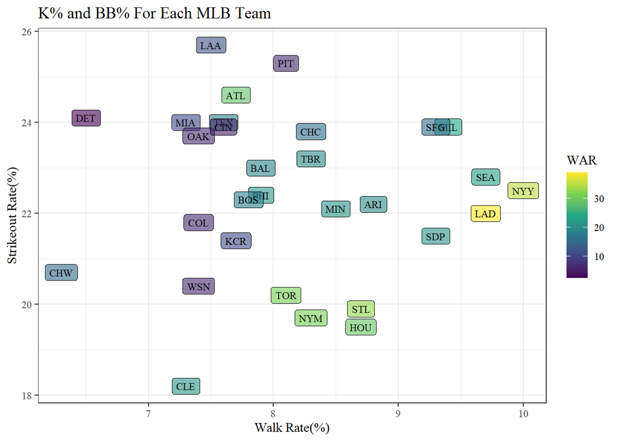

Following the same process as before, I got the 2022 Pitching Leaders. Without changing any settings on FanGraphs, the data frame downloaded has 22 variables and 45 observations.

```r
fg_pitch_leaders <- read_csv("fg_pitch_leaders.csv")
```

Name

Team

W

L

SV

G

GS

IP

K/9

BB/9

HR/9

BABIP

LOB%

GB%

HR/FB

vFA (pi)

ERA

xERA

FIP

xFIP

WAR

playerid

Aaron Nola

PHI

11

13

0

32

32

205.0

10.32

1.27

0.83

0.289

73.0%

43.6%

9.8%

92.9

3.25

2.74

2.58

2.77

6.3

16149

Carlos Rodon

SFG

14

8

0

31

31

178.0

11.98

2.63

0.61

0.293

75.1%

34.1%

6.5%

95.5

2.88

2.64

2.25

2.91

6.2

16137

Justin Verlander

HOU

18

4

0

28

28

175.0

9.51

1.49

0.62

0.240

80.5%

37.9%

6.2%

95.1

1.75

2.66

2.49

3.23

6.1

8700

Sandy Alcantara

MIA

14

9

0

32

32

228.2

8.15

1.97

0.63

0.262

78.8%

53.4%

8.5%

98.0

2.28

2.92

2.99

3.29

5.7

18684

Kevin Gausman

TOR

12

10

0

31

31

174.2

10.56

1.44

0.77

0.363

74.0%

39.2%

8.5%

94.9

3.35

3.34

2.38

2.75

5.7

14107

Shohei Ohtani

LAA

15

9

0

28

28

166.0

11.87

2.39

0.76

0.289

83.1%

41.9%

9.3%

97.4

2.33

2.68

2.40

2.65

5.6

19755

Max Fried

ATL

14

7

0

30

30

185.1

8.26

1.55

0.58

0.280

78.2%

51.2%

7.8%

94.0

2.48

2.85

2.70

3.09

5.0

13743

Shane Bieber

CLE

13

8

0

31

31

200.0

8.91

1.62

0.81

0.287

75.8%

48.2%

10.4%

91.5

2.88

3.51

2.87

2.98

4.9

19427

Corbin Burnes

MIL

12

8

0

33

33

202.0

10.83

2.27

1.02

0.259

76.8%

47.0%

14.1%

96.2

2.94

3.05

3.14

2.85

4.6

19361

Framber Valdez

HOU

17

6

0

31

31

201.1

8.67

3.00

0.49

0.285

75.7%

66.5%

12.5%

94.0

2.82

3.31

3.06

2.99

4.4

17295

Dylan Cease

CHW

14

8

0

32

32

184.0

11.10

3.82

0.78

0.260

82.3%

38.8%

8.4%

96.9

2.20

2.70

3.10

3.50

4.4

18525

Zac Gallen

ARI

12

4

0

31

31

184.0

9.39

2.30

0.73

0.237

78.0%

46.0%

9.1%

93.9

2.54

3.17

3.05

3.31

4.3

19291

Yu Darvish

SDP

16

8

0

30

30

194.2

9.11

1.71

1.02

0.250

78.2%

36.9%

9.6%

95.0

3.10

3.49

3.31

3.58

4.2

13074

Logan Webb

SFG

15

9

0

32

32

192.1

7.63

2.29

0.51

0.293

71.8%

56.7%

8.3%

92.4

2.90

3.59

3.03

3.31

4.2

17995

Alek Manoah

TOR

16

7

0

31

31

196.2

8.24

2.33

0.73

0.244

82.6%

37.5%

7.1%

93.9

2.24

3.31

3.35

3.97

4.1

26410

Tyler Anderson

LAD

15

5

0

30

28

178.2

6.95

1.71

0.71

0.256

77.8%

40.1%

6.4%

90.7

2.57

3.10

3.31

4.10

4.0

12880

Jose Quintana

6

7

0

32

32

165.2

7.44

2.55

0.43

0.302

74.2%

46.4%

5.3%

91.3

2.93

3.86

2.99

3.72

4.0

11423

Martin Perez

TEX

12

8

0

32

32

196.1

7.75

3.16

0.50

0.295

77.0%

51.4%

6.5%

92.9

2.89

3.59

3.27

3.80

3.8

6902

Triston McKenzie

CLE

11

11

0

31

30

191.1

8.94

2.07

1.18

0.237

80.3%

32.7%

10.3%

92.7

2.96

3.54

3.59

3.77

3.6

18000

Shane McClanahan

TBR

12

8

0

28

28

166.1

10.50

2.06

1.03

0.251

80.5%

50.2%

15.7%

97.0

2.54

2.79

3.00

2.60

3.5

21483

Joe Musgrove

SDP

10

7

0

30

30

181.0

9.15

2.09

1.09

0.276

79.8%

44.6%

12.3%

92.9

2.93

3.27

3.59

3.47

3.5

12970

Merrill Kelly

ARI

13

8

0

33

33

200.1

7.95

2.74

0.94

0.269

76.3%

42.8%

9.9%

92.4

3.37

3.62

3.65

3.86

3.3

11156

Gerrit Cole

NYY

13

8

0

33

33

200.2

11.53

2.24

1.48

0.268

78.2%

42.4%

16.8%

97.8

3.50

3.31

3.47

2.77

3.3

13125

Julio Urias

LAD

17

7

0

31

31

175.0

8.54

2.11

1.18

0.229

86.6%

39.7%

10.8%

93.1

2.16

2.81

3.71

3.81

3.2

14765

Logan Gilbert

SEA

13

6

0

32

32

185.2

8.43

2.38

0.92

0.292

77.6%

36.7%

9.2%

96.1

3.20

4.11

3.46

3.78

3.2

22250

Corey Kluber

TBR

10

10

0

31

31

164.0

7.63

1.15

1.10

0.317

70.2%

36.1%

9.3%

89.1

4.34

4.00

3.57

3.92

3.0

2429

Kyle Wright

ATL

21

5

0

30

30

180.1

8.68

2.65

0.95

0.284

78.9%

55.6%

14.4%

95.1

3.19

3.89

3.58

3.30

2.9

19665

Pablo Lopez

MIA

10

10

0

32

32

180.0

8.70

2.65

1.05

0.283

74.2%

46.1%

12.7%

93.5

3.75

3.75

3.71

3.56

2.8

17085

Adam Wainwright

STL

11

12

0

32

32

191.2

6.71

2.54

0.75

0.302

75.0%

43.2%

8.1%

88.1

3.71

4.53

3.66

4.10

2.8

2233

Miles Mikolas

STL

12

13

0

33

32

202.1

6.81

1.73

1.11

0.249

74.4%

45.0%

11.9%

93.6

3.29

3.89

3.87

3.80

2.8

9803

Jordan Montgomery

9

6

0

32

32

178.1

7.97

1.82

1.06

0.275

75.5%

47.6%

13.0%

93.1

3.48

4.00

3.61

3.43

2.7

16511

Chris Bassitt

NYM

15

9

0

30

30

181.2

8.27

2.43

0.94

0.282

77.2%

48.8%

10.9%

93.3

3.42

3.46

3.66

3.72

2.7

12304

Kyle Freeland

COL

9

11

0

31

31

174.2

6.75

2.73

0.98

0.318

70.5%

42.0%

9.5%

90.4

4.53

5.11

4.21

4.48

2.6

16256

Jameson Taillon

NYY

14

5

0

32

32

177.1

7.66

1.62

1.32

0.276

75.3%

40.1%

12.4%

94.1

3.91

4.20

3.94

3.79

2.3

11674

Cal Quantrill

CLE

15

5

0

32

32

186.1

6.18

2.27

1.01

0.278

76.4%

42.1%

9.6%

93.9

3.38

4.31

4.12

4.39

2.2

19312

Kyle Gibson

PHI

10

8

0

31

31

167.2

7.73

2.58

1.29

0.308

67.7%

45.9%

13.9%

92.3

5.05

4.46

4.28

3.94

1.8

10123

Robbie Ray

SEA

12

12

0

32

32

189.0

10.10

2.95

1.52

0.284

81.2%

39.2%

15.5%

93.6

3.71

3.59

4.17

3.58

1.8

11486

Charlie Morton

ATL

9

6

0

31

31

172.0

10.73

3.30

1.47

0.292

76.0%

39.8%

16.5%

94.9

4.34

4.11

4.26

3.60

1.5

4676

Nick Pivetta

BOS

10

12

0

33

33

179.2

8.77

3.66

1.35

0.300

75.3%

38.5%

12.4%

93.6

4.56

4.65

4.42

4.26

1.5

15454

Jordan Lyles

BAL

12

11

0

32

32

179.0

7.24

2.61

1.31

0.313

73.8%

40.2%

11.4%

91.9

4.42

4.94

4.40

4.39

1.4

7593

Cole Irvin

OAK

9

13

0

30

30

181.0

6.36

1.79

1.24

0.273

71.4%

37.7%

10.5%

90.9

3.98

4.40

4.21

4.35

1.4

19244

German Marquez

COL

9

13

0

31

31

181.2

7.43

3.12

1.49

0.291

68.1%

47.6%

16.9%

95.7

4.95

4.49

4.71

4.02

1.4

15038

Jose Berrios

TOR

12

7

0

32

32

172.0

7.80

2.35

1.52

0.328

70.9%

40.3%

13.5%

94.0

5.23

5.11

4.55

4.21

1.1

14168

Jose Urquidy

HOU

13

8

0

29

28

164.1

7.34

2.08

1.59

0.264

78.9%

36.0%

12.9%

93.6

3.94

4.56

4.60

4.32

1.1

18413

Marco Gonzales

SEA

10

15

0

32

32

183.0

5.07

2.46

1.48

0.277

73.7%

42.0%

12.3%

88.7

4.13

4.59

5.05

4.90

0.1

15467

Again, there are variable names with strange characters in them and this is a fairly small dataset. Next we will try accessing leaderboard data, but this time using the **baseballr** package.

## baseballr

There are [functions](https://billpetti.github.io/baseballr/reference/fangraphs.html) to access game logs, leaderboards, and park factors. The game logs and leaderboards each have separate functions for pitchers and for hitters.

```r
library(baseballr)
```

#### Game Logs

To access game logs for pitchers: `fg_pitcher_game_logs()` To access game logs for batters: `fg_batter_game_logs()` To access Minor League data: `fg_milb_pitcher_game_logs()` , `fg_milb_batter_game_logs()`

Both of these functions require input of ‘playerid’ and ‘year’. To find a player’s playerid search them on the [FanGraphs](https://www.fangraphs.com/) website. The playerid is the numbers after the player’s name in the URL. For example, to find Aaron Judge’s playerid look at his page: https://www.fangraphs.com/players/aaron-judge/15640/stats?position=OF. Aaron Judge’s FanGraphs player id is 15640.

```r
judge <- fg_batter_game_logs(playerid = 15640, year = 2021)
```

This produces a data frame with 245 variables. Each row is a different game played within the 2021 season.

```r
judge_filtered <- judge %>%
  dplyr::select(PlayerName, Date, Opp, Pos, AB:H, HR:BB, SO, `BB%`:BABIP, wOBA, EV:`HardHit%`)
```

| PlayerName | Date | Opp | Pos | AB | PA | H | HR | R | RBI | BB | SO | BB% | K% | BB/K | OBP | SLG | OPS | ISO | BABIP | wOBA | EV | LA | Barrels | Barrel% | maxEV | HardHit | HardHit% |
| --- | --- | --- | --- | --- | --- | --- | --- | --- | --- | --- | --- | --- | --- | --- | --- | --- | --- | --- | --- | --- | --- | --- | --- | --- | --- | --- | --- |
| Aaron Judge | 2021-08-29 | @OAK | RF | 4 | 4 | 0 | 0 | 0 | 0 | 0 | 0 | 0.00 | 0.0000000 | 0.0 | 0.00 | 0.0000000 | 0.000000 | 0.00 | 0.0000000 | 0.0000000 | 89.52336 | -1.2410349 | 0 | 0.0000000 | 107.3030 | 1 | 0.2500000 |
| Aaron Judge | 2021-05-02 | DET | RF | 3 | 3 | 0 | 0 | 0 | 0 | 0 | 1 | 0.00 | 0.3333333 | 0.0 | 0.00 | 0.0000000 | 0.000000 | 0.00 | 0.0000000 | 0.0000000 | 104.75067 | -1.3806877 | 1 | 0.5000000 | 108.0210 | 2 | 1.0000000 |
| Aaron Judge | 2021-09-21 | TEX | DH | 4 | 4 | 2 | 1 | 1 | 3 | 0 | 1 | 0.00 | 0.2500000 | 0.0 | 0.50 | 1.5000000 | 2.000000 | 1.00 | 0.5000000 | 0.8120413 | 106.43044 | 15.1964747 | 2 | 0.6666667 | 109.0790 | 3 | 1.0000000 |
| Aaron Judge | 2021-09-20 | TEX | RF | 3 | 4 | 2 | 0 | 1 | 1 | 1 | 0 | 0.25 | 0.0000000 | 1.0 | 0.75 | 0.6666667 | 1.416667 | 0.00 | 0.6666667 | 0.6124568 | 98.58771 | 21.7965978 | 0 | 0.0000000 | 105.7990 | 2 | 0.6666667 |
| Aaron Judge | 2021-07-08 | @SEA | RF | 4 | 4 | 0 | 0 | 0 | 0 | 0 | 1 | 0.00 | 0.2500000 | 0.0 | 0.00 | 0.0000000 | 0.000000 | 0.00 | 0.0000000 | 0.0000000 | 97.37162 | 2.9554113 | 1 | 0.3333333 | 115.3000 | 2 | 0.6666667 |
| Aaron Judge | 2021-05-17 | @TEX | RF | 3 | 4 | 0 | 0 | 0 | 0 | 1 | 1 | 0.25 | 0.2500000 | 1.0 | 0.25 | 0.0000000 | 0.250000 | 0.00 | 0.0000000 | 0.1729291 | 93.76357 | 3.8624806 | 0 | 0.0000000 | 101.4850 | 1 | 0.5000000 |
| Aaron Judge | 2021-05-20 | @TEX | PH-RF | 2 | 2 | 1 | 0 | 0 | 1 | 0 | 0 | 0.00 | 0.0000000 | 0.0 | 0.50 | 0.5000000 | 1.000000 | 0.00 | 0.5000000 | 0.4395277 | 98.72382 | 0.8749156 | 0 | 0.0000000 | 102.3630 | 2 | 1.0000000 |
| Aaron Judge | 2021-09-28 | @TOR | RF | 2 | 5 | 2 | 1 | 2 | 2 | 2 | 0 | 0.40 | 0.0000000 | 2.0 | 0.80 | 2.5000000 | 3.300000 | 1.50 | 0.5000000 | 0.8538014 | 99.95962 | 19.3179372 | 1 | 0.3333333 | 106.3640 | 2 | 0.6666667 |
| Aaron Judge | 2021-08-20 | MIN | RF | 4 | 5 | 1 | 1 | 2 | 2 | 1 | 2 | 0.20 | 0.4000000 | 0.5 | 0.40 | 1.0000000 | 1.400000 | 0.75 | 0.0000000 | 0.5396470 | 98.30936 | 37.4889565 | 1 | 0.5000000 | 106.9840 | 1 | 0.5000000 |
| Aaron Judge | 2021-08-07 | SEA | DH | 4 | 4 | 2 | 1 | 1 | 1 | 0 | 1 | 0.00 | 0.2500000 | 0.0 | 0.50 | 1.5000000 | 2.000000 | 1.00 | 0.5000000 | 0.8120413 | 108.35533 | 14.8720512 | 1 | 0.3333333 | 112.3110 | 3 | 1.0000000 |
| Aaron Judge | 2021-05-29 | @DET | DH | 4 | 4 | 0 | 0 | 0 | 0 | 0 | 1 | 0.00 | 0.2500000 | 0.0 | 0.00 | 0.0000000 | 0.000000 | 0.00 | 0.0000000 | 0.0000000 | 103.66392 | 17.9357452 | 0 | 0.0000000 | 111.3650 | 3 | 1.0000000 |
| Aaron Judge | 2021-04-16 | TBR | RF | 4 | 4 | 0 | 0 | 0 | 0 | 0 | 2 | 0.00 | 0.5000000 | 0.0 | 0.00 | 0.0000000 | 0.000000 | 0.00 | 0.0000000 | 0.0000000 | 86.13589 | 6.8525305 | 0 | 0.0000000 | 92.4342 | 0 | 0.0000000 |
| Aaron Judge | 2021-09-07 | TOR | CF | 4 | 4 | 0 | 0 | 0 | 0 | 0 | 0 | 0.00 | 0.0000000 | 0.0 | 0.00 | 0.0000000 | 0.000000 | 0.00 | 0.0000000 | 0.0000000 | 94.48032 | 32.2046852 | 0 | 0.0000000 | 99.8927 | 3 | 0.7500000 |
| Aaron Judge | 2021-08-03 | BAL | RF | 5 | 5 | 2 | 1 | 2 | 1 | 0 | 1 | 0.00 | 0.2000000 | 0.0 | 0.40 | 1.0000000 | 1.400000 | 0.60 | 0.3333333 | 0.5771148 | 85.68488 | 23.2170429 | 1 | 0.2500000 | 101.4950 | 1 | 0.2500000 |
| Aaron Judge | 2021-08-19 | MIN | CF-RF | 3 | 4 | 0 | 0 | 0 | 0 | 1 | 1 | 0.25 | 0.2500000 | 1.0 | 0.25 | 0.0000000 | 0.250000 | 0.00 | 0.0000000 | 0.1729291 | 101.00540 | -7.3106804 | 0 | 0.0000000 | 109.9380 | 1 | 0.5000000 |

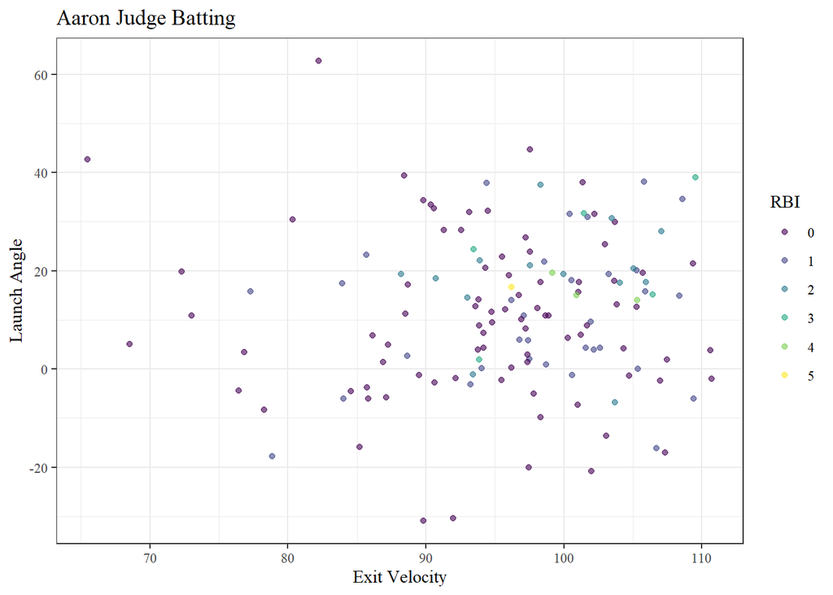

#### Leaderboards

To access leaderboards for pitchers: `fg_pitcher_leaders()` To access leaderboards for pitchers: `fg_batter_leaders()`

The arguments are ‘x’ for the first season of interest, ‘y’ for the last season of interest, ‘league’, and ‘pitcher_type’ (default is “pit” for all pitchers, other options are “sta” for starters and “rel” for relievers). There are additional optional arguments: ‘ind’, which specifies if if the data should look at one season or over many, and ‘league’, which determines if players must meet a certain qualification to be included (plate appearances for batters and innings per game for pitchers).

```r
pitch_leaders <- fg_pitcher_leaders(x = 2020, y = 2022)
```

The resulting data frame has 303 variables.

```r
pl_filtered <- pitch_leaders %>%
  dplyr::select(playerid:G, IP:BB, SO, Pitches, AVG:BABIP, WAR:Dollars)
```

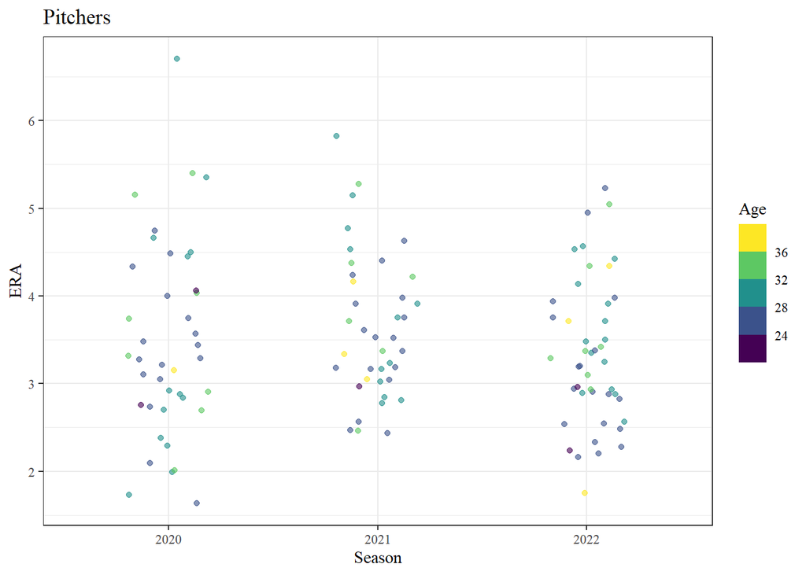

Accessing data from baseballr gives over double the amount of observations and hundreds of more variables.

There are also FanGraphs functions that can scrape [park factors](https://billpetti.github.io/baseballr/reference/fg_park.html).